# R Notebook

# Book 7

In this problem, you will use support vector approaches in order to predict whether a given car gets high or low gas mileage based on the Auto data set.

## (a)

Create a binary variable that takes on a 1 for cars with gas mileage above the median, and a 0 for cars with gas mileage below the median.

```r
Auto$mpg <- as.factor(ifelse(Auto$mpg > median(Auto$mpg), 1, 0))
```

## (b)

Fit a support vector classifier to the data with various values of cost, in order to predict whether a car gets high or low gas mileage. Report the cross-validation errors associated with different values of this parameter. Comment on your results.

When cost is .01, the error is 8.94%, which is the lowest in the range of values tested.

```r
set.seed(100)
tune.svm <- tune(svm, mpg~., data=Auto, kernel='linear', ranges=list(cost=c(.001, .01, .1, 1, 10, 100)))
summary(tune.svm)
```

```
Parameter tuning of ‘svm’:

- sampling method: 10-fold cross validation

- best parameters:
```

|  | cost |
| --- | --- |
|  | 0.01 |

```
- best performance: 0.08942308

- Detailed performance results:
```

| cost | error | dispersion |
| --- | --- | --- |
| 1e-03 | 0.12762821 | 0.07353560 |
| 1e-02 | 0.08942308 | 0.04419023 |
| 1e-01 | 0.09961538 | 0.05349840 |
| 1e+00 | 0.10448718 | 0.05563850 |
| 1e+01 | 0.12230769 | 0.05599171 |
| 1e+02 | 0.12230769 | 0.04903630 |

```
NA
```

## (c)

Now repeat (b), this time using SVMs with radial and polynomial basis kernels, with different values of gamma and degree and cost. Comment on your results.

The lowest cross-validation error was found to be 7.92%. This corresponded to a cost of 1 and gamma 1

```r
set.seed(100)
tune.svm <- tune(svm, mpg~., data=Auto, kernel='radial', ranges=list(cost=c(.001, .01, .1, 1, 10, 100), gamma=c(.0001, .001, .01, 1)))
summary(tune.svm)
```

```
Parameter tuning of ‘svm’:

- sampling method: 10-fold cross validation

- best parameters:
```

|  | cost | gamma |
| --- | --- | --- |
|  | 1 | 1 |

```
- best performance: 0.07929487

- Detailed performance results:
```

| cost | gamma | error | dispersion |
| --- | --- | --- | --- |
| 1e-03 | 1e-04 | 0.55115385 | 0.04842542 |
| 1e-02 | 1e-04 | 0.55115385 | 0.04842542 |
| 1e-01 | 1e-04 | 0.55115385 | 0.04842542 |
| 1e+00 | 1e-04 | 0.55115385 | 0.04842542 |
| 1e+01 | 1e-04 | 0.11230769 | 0.06739738 |
| 1e+02 | 1e-04 | 0.08685897 | 0.04239744 |
| 1e-03 | 1e-03 | 0.55115385 | 0.04842542 |
| 1e-02 | 1e-03 | 0.55115385 | 0.04842542 |
| 1e-01 | 1e-03 | 0.55115385 | 0.04842542 |
| 1e+00 | 1e-03 | 0.11487179 | 0.07368344 |

[output cut: 14 more lines]

```
NA
```

The best parameters were found to be .1 cost, 1 gamma, degree 3.

```r
set.seed(100)
tune.svm <- tune(svm, mpg~., data=Auto, kernel='polynomial', ranges=list(cost=c(.001, .01, .1, 1, 10, 100), gamma=c(.0001, .001, .01, 1), degree=c(1, 2, 3)))
summary(tune.svm)
```

```
Parameter tuning of ‘svm’:

- sampling method: 10-fold cross validation

- best parameters:
```

|  | cost | gamma | degree |
| --- | --- | --- | --- |
|  | 0.1 | 1 | 3 |

```
- best performance: 0.08416667

- Detailed performance results:
```

| cost | gamma | degree | error | dispersion |
| --- | --- | --- | --- | --- |
| 1e-03 | 1e-04 | 1 | 0.55115385 | 0.04842542 |
| 1e-02 | 1e-04 | 1 | 0.55115385 | 0.04842542 |
| 1e-01 | 1e-04 | 1 | 0.55115385 | 0.04842542 |
| 1e+00 | 1e-04 | 1 | 0.55115385 | 0.04842542 |
| 1e+01 | 1e-04 | 1 | 0.12762821 | 0.07353560 |
| 1e+02 | 1e-04 | 1 | 0.08942308 | 0.04419023 |
| 1e-03 | 1e-03 | 1 | 0.55115385 | 0.04842542 |
| 1e-02 | 1e-03 | 1 | 0.55115385 | 0.04842542 |
| 1e-01 | 1e-03 | 1 | 0.55115385 | 0.04842542 |
| 1e+00 | 1e-03 | 1 | 0.12762821 | 0.07353560 |

[output cut: 62 more lines]

```
NA
```

## (d)

Make some plots to back up your assertions in (b) and (c).

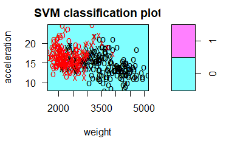

```r
svm.Auto <- svm(mpg~., data=Auto, kernel='linear', cost=1, scale=TRUE)
plot(svm.Auto, Auto, acceleration~weight)
```

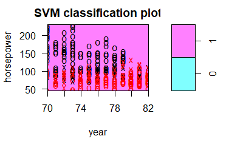

```r
plot(svm.Auto, Auto, horsepower~year)
```

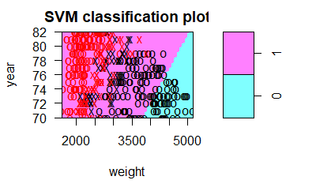

```r
plot(svm.Auto, Auto, year~weight)
```

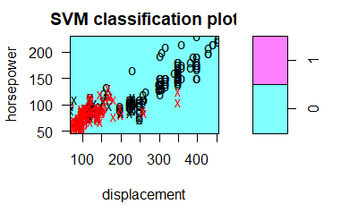

```r
plot(svm.Auto, Auto, horsepower~displacement)
```

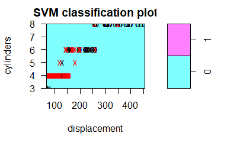

```r
plot(svm.Auto, Auto, cylinders~displacement)
```

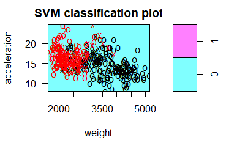

```r
svm.Auto <- svm(mpg~., data=Auto, kernel='polynomial', cost=.1, gamma=1, degree=3, scale=TRUE)
plot(svm.Auto, Auto, acceleration~weight)
```

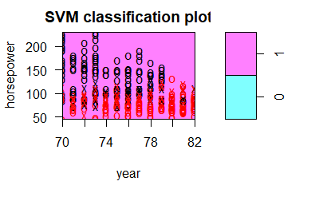

```r
plot(svm.Auto, Auto, horsepower~year)
```

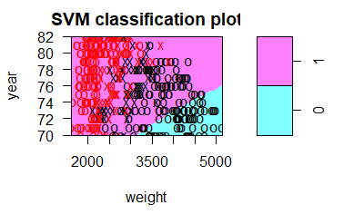

```r
plot(svm.Auto, Auto, year~weight)
```

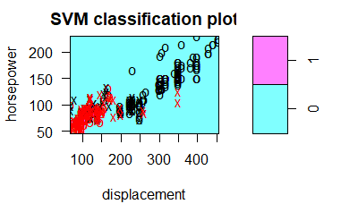

```r
plot(svm.Auto, Auto, horsepower~displacement)
```

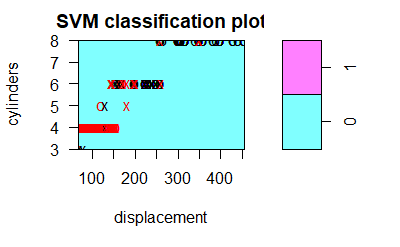

```r
plot(svm.Auto, Auto, cylinders~displacement)
```

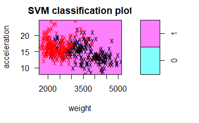

```r
svm.Auto <- svm(mpg~., data=Auto, kernel='radial', cost=1, gamma=1, scale=TRUE)
plot(svm.Auto, Auto, acceleration~weight)
```

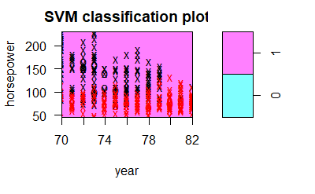

```r
plot(svm.Auto, Auto, horsepower~year)
```

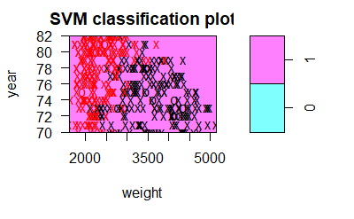

```r
plot(svm.Auto, Auto, year~weight)
```

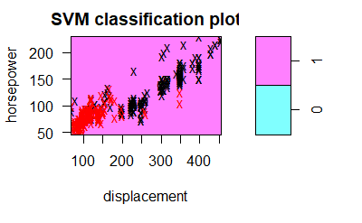

```r
plot(svm.Auto, Auto, horsepower~displacement)
```

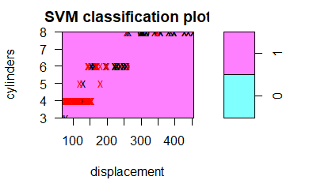

```r
plot(svm.Auto, Auto, cylinders~displacement)
```

# Book 8

This problem involves the OJ data set which is part of the ISLR package.

## (a)

Create a training set containing a random sample of 800 observations, and a test set containing the remaining observations.

```r
trainIdx <- sample(nrow(OJ), 800, replace=FALSE)
trainOJ <- OJ[trainIdx,]
testOJ <- OJ[-trainIdx,]
```

## (b)

Fit a support vector classifier to the training data using cost=.01, with Purchase as the response and the other variables as predictors. Use the summary() function to produce summary statistics and describe the results obtained.

The summary statistics show a classification svm is used with a linear kernel, so it is a svc model. The cost is .01 and gamma is .055. The number of support vectors is 455.

```r
svm.oj <- svm(Purchase~., data=trainOJ, cost=.01, kernel='linear')
summary(svm.oj)
```

```
Call:
svm(formula = Purchase ~ ., data = trainOJ, cost = 0.01, kernel = "linear")


Parameters:
   SVM-Type:  C-classification
 SVM-Kernel:  linear
       cost:  0.01
      gamma:  0.05555556

Number of Support Vectors:  455

 ( 228 227 )


Number of Classes:  2

Levels:
 CH MM
```

## (c)

What are the training and test error rates?

Training error is 18.1%. Test error is 14.07%

```r
# Training error rate
pred <- predict(svm.oj, newdata=trainOJ)
cm <- table(pred, trainOJ$Purchase)
cat('training error', (cm[2] + cm[3])/sum(cm))
```

```
training error 0.18125
```

```r
# Test error rate
pred <- predict(svm.oj, newdata=testOJ)
cm <- table(pred, testOJ$Purchase)
cat('\ntest error', (cm[2] + cm[3])/sum(cm))
```

```
test error 0.1407407
```

## (d)

Use the tune() function to select an optimal cost. Consider values in the range .01 to 10.

The optimal cost value is found to be 3.

```r
set.seed(100)
tune.oj <- tune(svm, Purchase~., data=trainOJ, kernel='linear', ranges=list(cost=c(.01, .1, 1, 2, 3, 4, 5, 6, 7, 8, 9, 10)))
summary(tune.oj)
```

```
Parameter tuning of ‘svm’:

- sampling method: 10-fold cross validation

- best parameters:
```

|  | cost |
| --- | --- |
|  | 3 |

```
- best performance: 0.18

- Detailed performance results:
```

| cost | error | dispersion |
| --- | --- | --- |
| 0.01 | 0.18750 | 0.03173239 |
| 0.10 | 0.18375 | 0.02889757 |
| 1.00 | 0.18375 | 0.03335936 |
| 2.00 | 0.18125 | 0.03397814 |
| 3.00 | 0.18000 | 0.03238227 |
| 4.00 | 0.18250 | 0.03184162 |
| 5.00 | 0.18250 | 0.03073181 |
| 6.00 | 0.18375 | 0.02949223 |
| 7.00 | 0.18375 | 0.02949223 |
| 8.00 | 0.18250 | 0.03073181 |

[output cut: 2 more lines]

```
NA
```

## (e)

Compute the training and test error rates using this new value for cost.

The training error is 17.6% and the test error is 14.07%.

```r
svm.oj <- svm(Purchase~., data=trainOJ, cost=3, kernel='linear')
```

```r
# Training error rate
pred <- predict(svm.oj, newdata=trainOJ)
cm <- table(pred, trainOJ$Purchase)
cat('training error', (cm[2] + cm[3])/sum(cm))
```

```
training error 0.17625
```

```r
# Test error rate
pred <- predict(svm.oj, newdata=testOJ)
cm <- table(pred, testOJ$Purchase)
cat('\ntest error', (cm[2] + cm[3])/sum(cm))
```

```
test error 0.1407407
```

## (f)

Repeat parts (b) through (e) using a support vector machine with a radial kernel. Use the default value for gamma.

The summary statistics show a classification svm is used with a radial kernel, so it is a svm model. The cost is .01 and gamma is .055. The number of support vectors is 641.

```r
set.seed(100)
svm.oj <- svm(Purchase~., data=trainOJ, cost=.01, kernel='radial')
summary(svm.oj)
```

```
Call:
svm(formula = Purchase ~ ., data = trainOJ, cost = 0.01, kernel = "radial")


Parameters:
   SVM-Type:  C-classification
 SVM-Kernel:  radial
       cost:  0.01
      gamma:  0.05555556

Number of Support Vectors:  641

 ( 322 319 )


Number of Classes:  2

Levels:
 CH MM
```

Training error is 39.87% and test error is 36.29%.

```r
# Training error rate
pred <- predict(svm.oj, newdata=trainOJ)
cm <- table(pred, trainOJ$Purchase)
cat('training error', (cm[2] + cm[3])/sum(cm))
```

```
training error 0.39875
```

```r
# Test error rate
pred <- predict(svm.oj, newdata=testOJ)
cm <- table(pred, testOJ$Purchase)
cat('\ntest error', (cm[2] + cm[3])/sum(cm))
```

```
test error 0.362963
```

The optimal cost value is found to be 1.

```r
set.seed(100)
tune.oj <- tune(svm, Purchase~., data=trainOJ, kernel='radial', ranges=list(cost=c(.01, .1, 1, 2, 3, 4, 5, 6, 7, 8, 9, 10)))
summary(tune.oj)
```

```
Parameter tuning of ‘svm’:

- sampling method: 10-fold cross validation

- best parameters:
```

|  | cost |
| --- | --- |
|  | 1 |

```
- best performance: 0.19125

- Detailed performance results:
```

| cost | error | dispersion |
| --- | --- | --- |
| 0.01 | 0.39875 | 0.06908379 |
| 0.10 | 0.19375 | 0.03346329 |
| 1.00 | 0.19125 | 0.04168749 |
| 2.00 | 0.20000 | 0.03280837 |
| 3.00 | 0.19750 | 0.04199868 |
| 4.00 | 0.19750 | 0.04779877 |
| 5.00 | 0.19625 | 0.04825065 |
| 6.00 | 0.19625 | 0.04825065 |
| 7.00 | 0.19750 | 0.04993051 |
| 8.00 | 0.19625 | 0.04931827 |

[output cut: 2 more lines]

```
NA
```

```r
svm.oj <- svm(Purchase~., data=trainOJ, cost=1, kernel='radial')
```

The training error is 16.25% and the test error is 12.59%.

```r
# Training error rate
pred <- predict(svm.oj, newdata=trainOJ)
cm <- table(pred, trainOJ$Purchase)
cat('training error', (cm[2] + cm[3])/sum(cm))
```

```
training error 0.1625
```

```r
# Test error rate
pred <- predict(svm.oj, newdata=testOJ)
cm <- table(pred, testOJ$Purchase)
cat('\ntest error', (cm[2] + cm[3])/sum(cm))
```

```
test error 0.1259259
```

## (g)

Repeat parts (b) t hrough (e) using a support vector machine with a polynomial kernel. Set degree=2.

The summary statistics show a classification svm is used with a polynomial kernel, so it is a svm model. The cost is .01, degree is 2, and gamma is .055. The number of support vectors is 644.

```r
set.seed(100)
svm.oj <- svm(Purchase~., data=trainOJ, cost=.01, kernel='polynomial', degree=2)
summary(svm.oj)
```

```
Call:
svm(formula = Purchase ~ ., data = trainOJ, cost = 0.01, kernel = "polynomial", degree = 2)


Parameters:
   SVM-Type:  C-classification
 SVM-Kernel:  polynomial
       cost:  0.01
     degree:  2
      gamma:  0.05555556
     coef.0:  0

Number of Support Vectors:  644

 ( 325 319 )


Number of Classes:  2

Levels:
 CH MM
```

Training error is 37.62% and test error is 35.18%.

```r
# Training error rate
pred <- predict(svm.oj, newdata=trainOJ)
cm <- table(pred, trainOJ$Purchase)
cat('training error', (cm[2] + cm[3])/sum(cm))
```

```
training error 0.37625
```

```r
# Test error rate
pred <- predict(svm.oj, newdata=testOJ)
cm <- table(pred, testOJ$Purchase)
cat('\ntest error', (cm[2] + cm[3])/sum(cm))
```

```
test error 0.3518519
```

The optimal cost value is found to be 8.

```r
set.seed(100)
tune.oj <- tune(svm, Purchase~., data=trainOJ, kernel='polynomial', ranges=list(cost=c(.01, .1, 1, 2, 3, 4, 5, 6, 7, 8, 9, 10)), degree=2)
summary(tune.oj)
```

```
Parameter tuning of ‘svm’:

- sampling method: 10-fold cross validation

- best parameters:
```

|  | cost |
| --- | --- |
|  | 8 |

```
- best performance: 0.20125

- Detailed performance results:
```

| cost | error | dispersion |
| --- | --- | --- |
| 0.01 | 0.39500 | 0.07100469 |
| 0.10 | 0.34000 | 0.05197489 |
| 1.00 | 0.20750 | 0.03496029 |
| 2.00 | 0.20625 | 0.03644345 |
| 3.00 | 0.20625 | 0.04050463 |
| 4.00 | 0.20250 | 0.03476109 |
| 5.00 | 0.20375 | 0.03283481 |
| 6.00 | 0.20125 | 0.03793727 |
| 7.00 | 0.20250 | 0.03622844 |
| 8.00 | 0.20125 | 0.03557562 |

[output cut: 2 more lines]

```
NA
```

```r
svm.oj <- svm(Purchase~., data=trainOJ, cost=8, kernel='polynomial', degree=2)
```

The training error is 17.00% and the test error is 15.55%.

```r
# Training error rate
pred <- predict(svm.oj, newdata=trainOJ)
cm <- table(pred, trainOJ$Purchase)
cat('training error', (cm[2] + cm[3])/sum(cm))
```

```
training error 0.17
```

```r
# Test error rate
pred <- predict(svm.oj, newdata=testOJ)
cm <- table(pred, testOJ$Purchase)
cat('\ntest error', (cm[2] + cm[3])/sum(cm))
```

```
test error 0.1555556
```

## (h)

Overall, which approach seems to give the best results on this data?

The radial kernel gave the lowest test error when optimized. Therefore, this is the best svm model.

# Extra 63

In this problem, we use the BreastCancer data, which comes as part of the package mlbench. Install the package and read the description of the data.

We want to predict the class of an observation (benign or malignant).

## (a)

Fit a logistic model to the data. Plot the ROC curve.

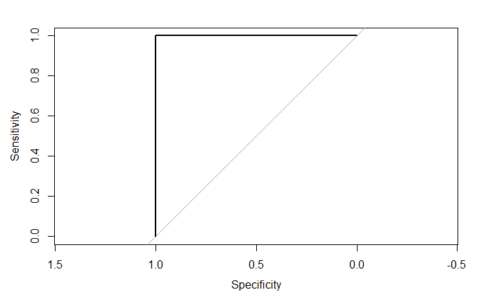

```r
log.bc <- suppressWarnings(glm(y~., data=BreastCancer[-1], family='binomial', maxit=1000))
pred <- predict(log.bc, BreastCancer[-1], type='response')
plot(roc(BreastCancer$y, pred))
```

## (b)

Use a support vector classifier (linear kernels) to classify. Plot the ROC curve in the plot oyu made in part a

[output not shown]

```r
svm.bc <- svm(y~., data=BreastCancer[-1], kernel='linear', cost=1)
pred <- as.numeric((predict(svm.bc, newdata=BreastCancer[-1], decision.values=TRUE)))
roc(BreastCancer$y, pred)
```